# MA, AR, dan ARMA

Farhan Abdillah Harahap (G1401211007)

2023-09-21

## White Noise

Pembangkitan data berpola AR, MA, ARMA, dan banyak proses deret waktu lainnya diawali pembangkitan *white noise*. *White noise* merupakan sederet nilai dari peubah bebas stokastik identik. Oleh karena itu, *white noise* memiliki dua karakteristik penting:

1. *White noise* tidak memiliki autokorelasi (**karena saling bebas**)
2. Nilai harapan dan ragam *white noise* sama (**karena berasal dari peubah acak bebas stokastik identik**)

*White noise* dibangkitkan dari suatu peubah acak, umumnya peubah acak normal.

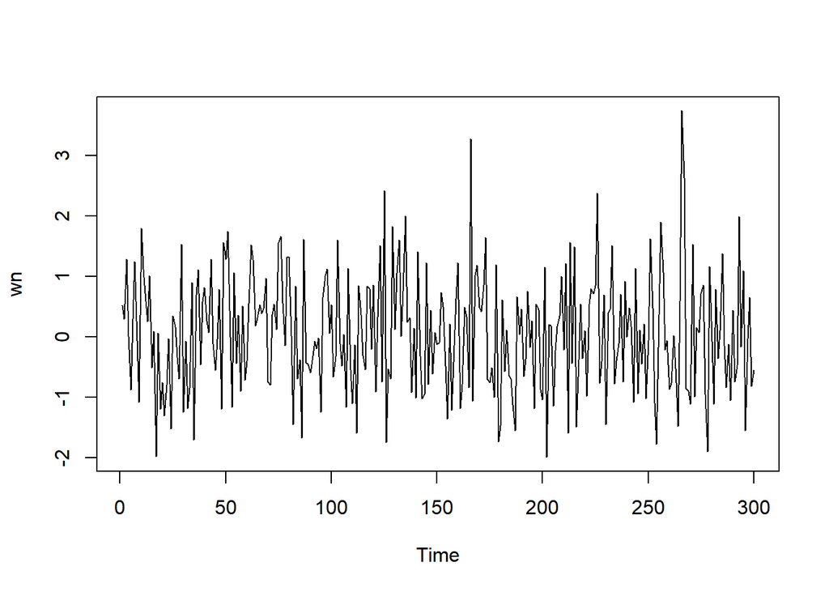

```r
set.seed(1007)
wn <- rnorm(300)
ts.plot(wn)
```

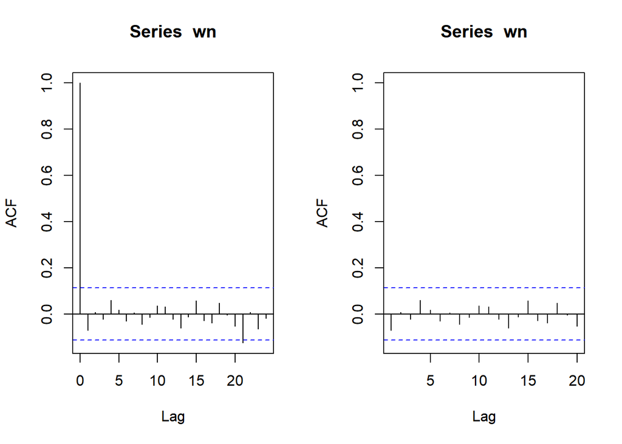

```r
par(mfrow = c(1, 2))
acf(wn)
acf(wn, xlim = c(1, 20))
```

Dapat terlihat bahwa *white noise* tidak memiliki autokorelasi dari ACF. Perhatikan bahwa lag ke-0 adalah korelasi observasi ke-t dengan dirinya sendiri. Nilai korelasi tersebut pasti 1. Sebagai alternatif, lag pertama di plot ACF dapat ditetapkan sebagai 1 (alih-alih 0) dengan menambahkan argumen `xlim(1, lag akhir)`. Plot tersebut dapat disandingkan bersamaan dengan membuat matriks $1 \times 2$ dengan `par(mfrow = c(1,2))`.

# Proses MA

Proses MA dapat dituliskan sebagai berikut:

$$y_{t} = c + e_t + \theta_{1}e_{t-1} + \theta_{2}e_{t-2} + \dots +
\theta_{q}e_{t-q} = c+{e_t+\sum_{i=1}^p \theta_ie_{t-i}}$$

Terlihat bahwa $e_t$, atau *white noise*, berperan penting dalam pembangkitan proses MA.

## Pembangkitan Proses MA(2)

Akan dicoba membangkitkan proses MA paling sederhana, yaitu MA(2) dengan $\theta1 = 0.4, theta2 = 0.6$ sebanyak 300 observasi dan $c=0$. Karena diperlukan dua nilai awal untuk $e_{t-1}, e_{t-2}$, masukkan nilai pertama dan kedua white noise sebagai nilai awal tersebut.

```r
set.seed(1007)
ma <- wn[c(1,2)]
```

Nilai-nilai selanjutnya dapat dicari melalui *loop*. Bentuk loop dapat dilihat dari rumus MA(2) yang hendak dibangkitkan:

$$y_t = e_t+0.4e_{t-1}+0.6e_{t-2}$$

```r
set.seed(1007)
for(i in 3:300){
   ma[i] <- wn[i] + 0.4 * wn[i - 1] + 0.6 * wn[i-2]
}
ma
```

```
##   [1]  0.520874229  0.293175799  1.720458098  0.704045991 -0.096088084
##   [6] -0.048906471  0.842980504  0.619493815 -0.353457685  1.326993538
##  [11]  1.188080198  2.111958757  1.159323833  1.465077065  0.045987388
##  [16]  0.494795985 -2.244096638 -0.676903122 -2.359452063 -1.198915349
##  [21] -2.324930386 -1.772420693 -1.132358056 -2.005558287 -0.277576501
##  [26] -0.604211065 -0.060018359 -0.724841271  1.050915276 -1.047392237
##  [31]  0.344271951 -1.962645104 -1.367791022 -0.148785293 -1.855566337
##  [36]  0.552465772  0.366402192  0.400575195  1.065006330  0.770161798
##  [41]  0.936511794  0.669537456  1.470301486  0.447528403  0.174448015
##  [46] -0.331629556  0.436433792 -0.901063932  1.562788988  1.201427893
##  [51]  3.199943963  1.475967667 -0.115778736  0.597993161 -0.711803890
##  [56]  0.818563965 -1.011909894  0.371998367 -1.044548080 -0.378119506
##  [61] -0.038928890  1.504996516  2.219635449  1.609310087  1.159066752
##  [66]  0.772324890  0.793600032  0.949081074  1.396640830 -0.069826900
##  [71] -0.511754923 -0.395938427  0.206817176  0.564321214  1.922592849
```

[output cut: 45 more lines]

Selain menggunakan cara di atas, pembangkitan proses MA(2) dapat dilakukan dengan fungsi `arima.sim()` sebagai berikut.

```r
set.seed(1007)
ma <- arima.sim(list(order=c(0,0,2), ma= c(0.4,0.6)), n=300)
ma
```

```
## Time Series:
## Start = 1
## End = 300
## Frequency = 1
##   [1]  1.720458098  0.704045991 -0.096088084 -0.048906471  0.842980504
##   [6]  0.619493815 -0.353457685  1.326993538  1.188080198  2.111958757
##  [11]  1.159323833  1.465077065  0.045987388  0.494795985 -2.244096638
##  [16] -0.676903122 -2.359452063 -1.198915349 -2.324930386 -1.772420693
##  [21] -1.132358056 -2.005558287 -0.277576501 -0.604211065 -0.060018359
##  [26] -0.724841271  1.050915276 -1.047392237  0.344271951 -1.962645104
##  [31] -1.367791022 -0.148785293 -1.855566337  0.552465772  0.366402192
##  [36]  0.400575195  1.065006330  0.770161798  0.936511794  0.669537456
##  [41]  1.470301486  0.447528403  0.174448015 -0.331629556  0.436433792
##  [46] -0.901063932  1.562788988  1.201427893  3.199943963  1.475967667
##  [51] -0.115778736  0.597993161 -0.711803890  0.818563965 -1.011909894
```

[output cut: 49 more lines]

## Karakteristik MA(2)

### TS, ACF, PACF

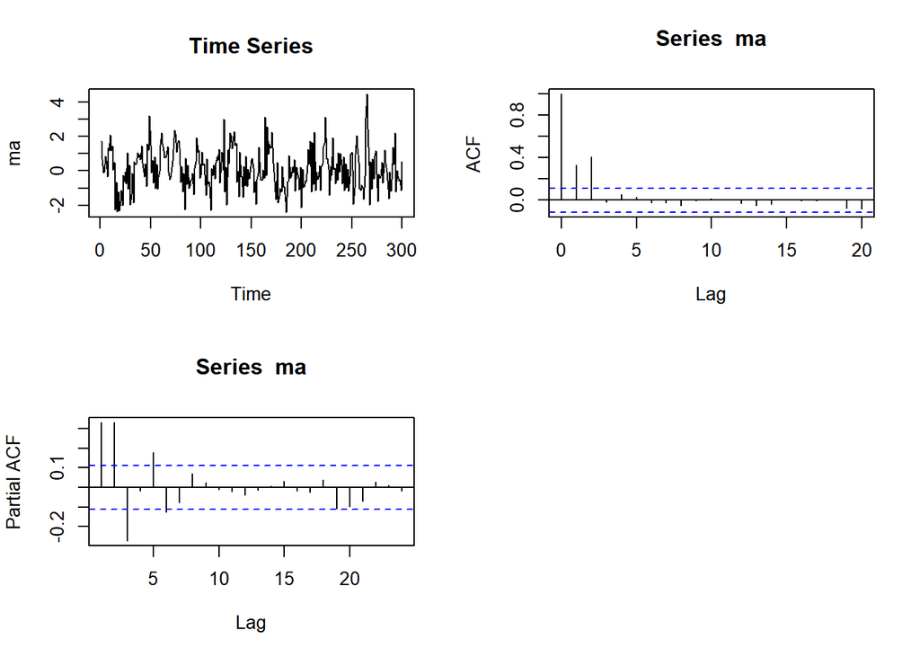

```r
par(mfrow = c(2, 2))

# Plot Time Series
ts.plot(ma)
title("Time Series")

# Plot ACF
acf(ma, lag.max = 20)

# Plot PACF
pacf(ma)
```

Dari Ketiga poin tersebut, data tergolong stasioner.

### Plot EACF

```r
TSA::eacf(ma)
```

```
## AR/MA
##   0 1 2 3 4 5 6 7 8 9 10 11 12 13
## 0 x x o o o o o o o o o  o  o  o
## 1 x x o o o o o o o o o  o  o  o
## 2 x x x x o o o o o o o  o  o  o
## 3 o x o x o o o o o o o  o  o  o
## 4 o x x o x o o o o o o  o  o  o
## 5 x x x o x x x o o o o  o  o  o
## 6 x x o x o o o o o o o  o  o  o
## 7 x x o o o o o o o o o  o  o  o
```

Membentuk segitiga pada p=0, q=2 (AR(0) dan MA(2)). Oleh karena itu, kandidat model dari EACF adalah ARIMA(0,0,2)

### Scatterplot dan Korelasi Antar Lag

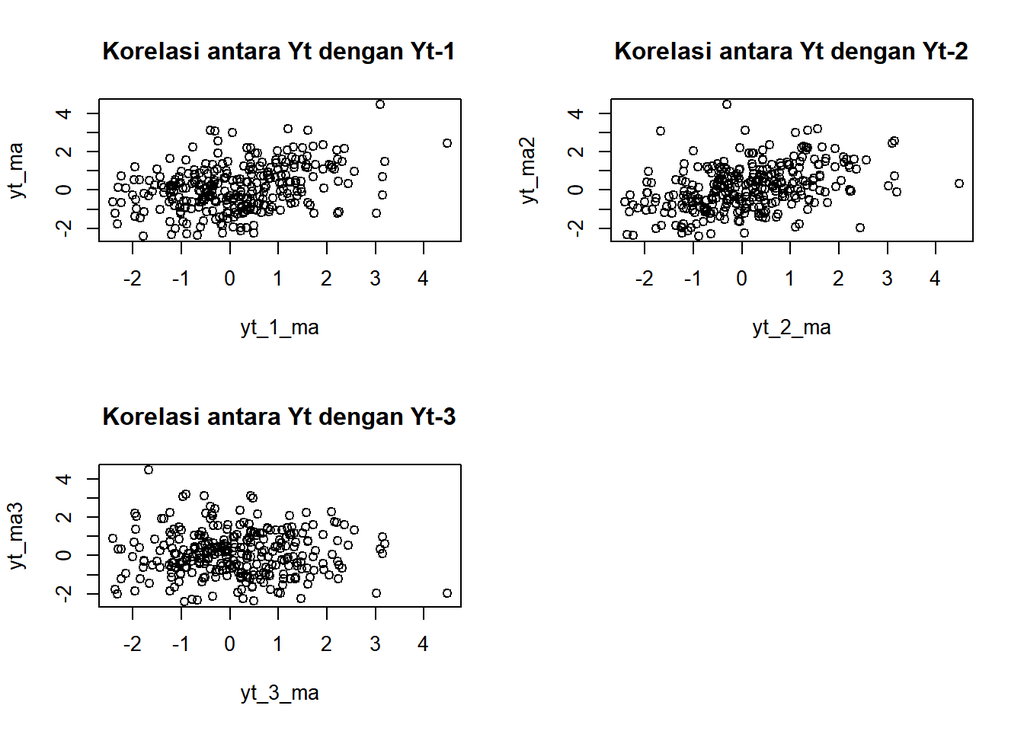

```r
# Set up the plot layout
par(mfrow=c(2,2))

# Korelasi antara Yt dengan Yt-1
# Yt
yt_ma <- ma[-1]
# Yt-1
yt_1_ma <- ma[-300]
plot(y=yt_ma,x=yt_1_ma, main="Korelasi antara Yt dengan Yt-1")
cor_1 <- cor(yt_ma,yt_1_ma)

# Korelasi antara Yt dengan Yt-2
# Yt
yt_ma2 <- ma[-c(1,2)]
# Yt-2
yt_2_ma <- ma[-c(299,300)]
plot(y=yt_ma2,x=yt_2_ma, main="Korelasi antara Yt dengan Yt-2")
cor_2 <- cor(yt_ma2,yt_2_ma)

# Korelasi antara Yt dengan Yt-3
# Yt
yt_ma3 <- ma[-c(1,2,3)]
# Yt-3
yt_3_ma <- ma[-c(298,299,300)]
plot(y=yt_ma3,x=yt_3_ma, main="Korelasi antara Yt dengan Yt-3")
cor_3 <- cor(yt_ma3,yt_3_ma)

# Reset the plot layout
par(mfrow=c(1,1))
```

```r
# Tabel Korelasi
cor_table <- data.frame(Yt_1 = cor_1, Yt_2 = cor_2, Yt_3 = cor_3)
print(cor_table)
```

```
##        Yt_1      Yt_2        Yt_3
## 1 0.3330561 0.4082187 -0.01571494
```

Berdasarkan scatterplot tersebut, terdapat hubungan linear positif antara $Y_t$ dengan $Y_{t-1}$ dan $Y_{t-2}$. Namun, tidak ada hubungan antara $Y_t$ dengan $Y_{t-3}$. Begitupula dengan korelasinya yang menurun drastis saat $Y_{t-3}$. Hal ini bersesuaian dengan Teori.

# Proses AR

Proses AR dapat dituliskan sebagai berikut:

$$y_{t} = c + e_t + \phi_{1}Y_{t-1} +
\phi_{2}Y_{t-2} + \dots + \phi_{q}Y_{t-q} = c+{e_t+\sum_{i=1}^p
\phi_iY_{t-i}}$$
Terlihat bahwa $Y_t$ berperan penting dalam pembangkitan proses AR.

## Pembangkitan Proses AR

Akan dicoba AR(2) dengan $\phi1 = 0.5$ dan $\phi2 = 0.2$ sebanyak 300 observasi dan $c=0$.

```r
set.seed(1007)
```

$$Y_t = e_t+0.5Y_{t-1}+0.2Y_{t-2}$$

```r
set.seed(1007)
n<-length(wn)
n
```

```
## [1] 300
```

```r
set.seed(1007)
ar <- c(2:n)
for (i in 3:n) {ar[i]<-wn[i]+0.5*ar[i-1]+0.2*ar[i-2]}
ar
```

```
##   [1]  2.00000000  3.00000000  3.19066324  2.20720684  0.86649995  1.16875419
##   [7]  2.00817412  1.18069519 -0.08891640  1.98531953  2.09404050  2.03219409
##  [13]  1.68748659  2.26136064  0.95814475  1.02344653 -1.27156550 -0.37329070
##  [19] -1.63858098 -1.64849661 -2.45650218 -2.35582724 -1.69969878 -2.83565314
##  [25] -1.41119667 -1.10678491 -1.16996956 -1.49701436  0.54528589 -1.27086340
##  [31] -0.60113337 -1.74101885 -1.83916002 -0.36543181 -2.25800068 -0.50805100
##  [37]  0.40763394 -0.35894329  0.48356575  0.98424181  0.85074045  0.69844493
##  [43]  1.80203767  0.92943357  0.27448177  0.27851961  0.97881868 -0.64305089
##  [49]  1.44149543  1.87956106  2.97269989  1.86792760  0.36368670  1.61594960
##  [55]  0.44359020  0.90208532 -0.35271615  0.51878792 -0.52610281 -0.56026927
##  [61]  0.16507822  1.49589367  2.06017451  1.51164621  1.48644545  1.58101375
##  [67]  1.47605882  1.52673102  2.03326085  0.57877698 -0.10324455  0.43382857
##  [73]  0.73477550  0.58125336  1.98622860  2.77468269  2.34603751  1.58646866
##  [79]  2.58261118  2.93695295  2.00391722  0.14257861  1.31127240 -0.01050718
##  [85] -0.11659129 -1.73106323  0.72671190 -0.41133590 -0.50469968 -0.92640280
```

[output cut: 35 more lines]

Selain menggunakan cara di atas, pembangkitan proses AR dapat dilakukan dengan fungsi `arima.sim()` sebagai berikut.

```r
set.seed(1007)
ar <- arima.sim(list(order=c(2,0,0), ar=c(0.5,0.2)), n=300)
ar
```

```
## Time Series:
## Start = 1
## End = 300
## Frequency = 1
##   [1] -1.10991601 -1.17235654 -1.49883407  0.54389863 -1.27192097 -0.60193960
##   [7] -1.74163348 -1.83962858 -0.36578902 -2.25827300 -0.50825860  0.40747567
##  [13] -0.35906394  0.48347377  0.98417169  0.85068699  0.69840418  1.80200660
##  [19]  0.92940989  0.27446371  0.27850585  0.97880818 -0.64305889  1.44148933
##  [25]  1.87955641  2.97269634  1.86792490  0.36368464  1.61594803  0.44358901
##  [31]  0.90208441 -0.35271685  0.51878739 -0.52610322 -0.56026958  0.16507798
##  [37]  1.49589349  2.06017438  1.51164611  1.48644537  1.58101369  1.47605877
##  [43]  1.52673099  2.03326082  0.57877696 -0.10324456  0.43382856  0.73477549
##  [49]  0.58125335  1.98622859  2.77468269  2.34603751  1.58646866  2.58261118
##  [55]  2.93695294  2.00391722  0.14257861  1.31127240 -0.01050718 -0.11659129
##  [61] -1.73106323  0.72671189 -0.41133590 -0.50469968 -0.92640280 -0.94630336
```

[output cut: 39 more lines]

## Karakteristik AR(2)

### TS, ACF, dan PACF

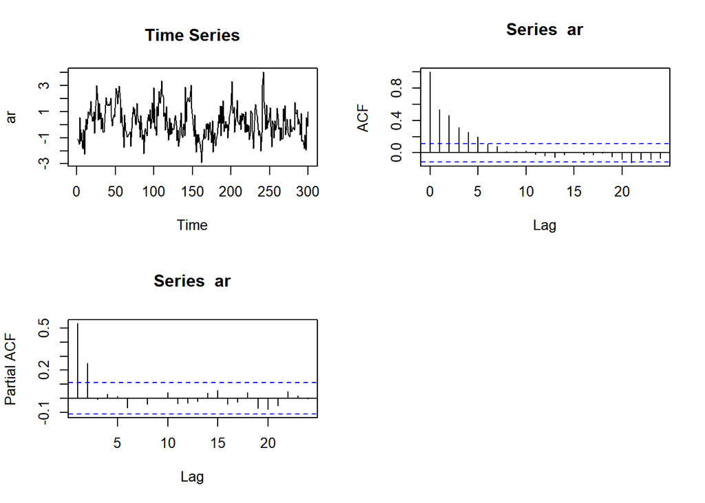

```r
par(mfrow=c(2,2))

# Plot Time Series
ts.plot(ar)
title("Time Series")

# Plot ACF
acf(ar)

# Plot PACF
pacf(ar)

# Reset the plot layout
par(mfrow=c(1,1))
```

Dari Ketiga poin tersebut, data tergolong stasioner.

### Plot EACF

```r
TSA::eacf(ar)
```

```
## AR/MA
##   0 1 2 3 4 5 6 7 8 9 10 11 12 13
## 0 x x x x x o o o o o o  o  o  o
## 1 x x o o o o o o o o o  o  o  o
## 2 o o o o o o o o o o o  o  o  o
## 3 x o o o o o o o o o o  o  o  o
## 4 x x o x o o o o o o o  o  o  o
## 5 x x o x o o o o o o o  o  o  o
## 6 o x o x o o o o o o o  o  o  o
## 7 o x o x x x o o o o o  o  o  o
```

### Scatterplot dan Korelasi

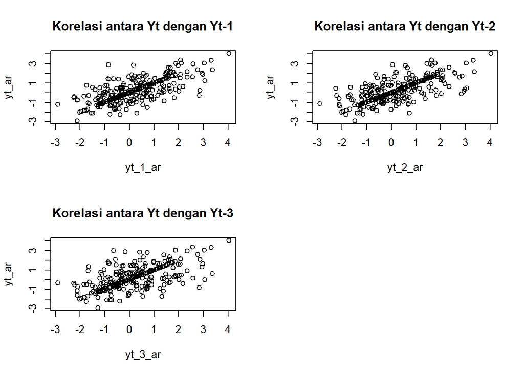

```r
par(mfrow=c(2,2))

# Korelasi antara Yt dengan Yt-1
# Yt
yt_ar <- ar[-1]
# Yt-1
yt_1_ar <- ar[-200]
plot(y=yt_ar,x=yt_1_ar, main="Korelasi antara Yt dengan Yt-1")
cor_1 <- cor(yt_ar,yt_1_ar)

# Korelasi antara Yt dengan Yt-2
# Yt
yt_ar <- ar[-c(1,2)]
# Yt-2
yt_2_ar <- ar[-c(199,200)]
plot(y=yt_ar,x=yt_2_ar, main="Korelasi antara Yt dengan Yt-2")
cor_2 <- cor(yt_ar,yt_2_ar)

# Korelasi antara Yt dengan Yt-3
# Yt
yt_ar <- ar[-c(1,2,3)]
# Yt-3
yt_3_ar <- ar[-c(198,199,200)]
plot(y=yt_ar,x=yt_3_ar, main="Korelasi antara Yt dengan Yt-3")
cor_3 <- cor(yt_ar,yt_3_ar)

# Reset the plot layout
par(mfrow=c(1,1))
```

```r
# Tabel Korelasi
cor_table <- data.frame(Yt_1 = cor_1, Yt_2 = cor_2, Yt_3 = cor_3)
print(cor_table)
```

```
##        Yt_1      Yt_2      Yt_3
## 1 0.7004383 0.6970893 0.5992686
```

Berdasarkan scatterplot tersebut, terdapat hubungan linear positif antara $Y_t$ dengan $Y_{t-1}$, $Y_{t-2}$, $Y_{t-3}$. Penurunan tingkat korelasi antara $Y_t$,$Y_{t-2}$ ke $Y_t$,$Y_{t-3}$ cukup jauh menurun sebesar 0.1.

#Proses ARMA

## Fungsi pembangkitan ARMA

Pertama, lihat kembali bentuk umum data berpola ARMA.

$$y_{t} = c + \sum_{i=1}^p \phi_{i}y_{t-i} + \sum_{j=1}^q e_{t-j}+ e_{t}$$

```r
#membuat fungsi dari model ARMA(2,2)
set.seed(1007)

n = length(wn)
phi1 = 0.5
phi2 = 0.2
theta1 = 0.4
theta2 = 0.6

arma=c(1:n)
for (i in 3:n){
arma[i] = phi1*arma[i-1] + phi2*arma[i-2] + theta1*wn[i-1] + theta2*wn[i-2]+wn[i]
}
arma
```

```
##   [1]  1.00000000  2.00000000  2.92045810  2.56427504  1.77014106  1.34901906
##   [7]  1.87151825  1.82505675  0.93337434  2.15869206  2.45410110  3.77074772
##  [13]  3.53551791  3.98698556  2.74658375  2.66548497 -0.36203740 -0.32482483
##  [19] -2.59427196 -2.56101629 -4.12429292 -4.34677041 -4.13060185 -4.94021329
##  [25] -3.57380352 -3.37915548 -2.46435680 -2.63285077 -0.75838147 -1.95315313
##  [31] -0.78398091 -2.74526618 -2.89722029 -2.14644868 -3.50823473 -1.63094133
##  [37] -1.15071542 -0.50097078  0.58437786  0.96215657  1.53446565  1.62920159
##  [43]  2.59179541  2.06926643  1.72744031  0.94594389  1.25489380 -0.08442826
##  [49]  1.77155362  2.07031905  4.58941421  4.18473858  2.89447340  2.88217758
##  [55]  1.30817958  2.04908927  0.27427066  0.91895155 -0.53021817 -0.45943828
##  [61] -0.37469167  1.22576303  2.75757863  3.23325201  3.32720848  3.08257953
##  [67]  3.00033149  3.06576273  3.52958849  2.30811989  1.34822272  0.73979691
##  [73]  0.84636018  1.13546068  2.65959523  3.91792614  4.64764774  4.18969327
##  [79]  4.62482115  4.92187861  4.72826510  2.70631726  2.57065417  0.59954895
##  [85]  0.66596928 -1.78400405 -0.03566817 -1.15928908 -0.23320691 -1.37508421
```

[output cut: 35 more lines]

```r
arma
```

```
##   [1]  1.00000000  2.00000000  2.92045810  2.56427504  1.77014106  1.34901906
##   [7]  1.87151825  1.82505675  0.93337434  2.15869206  2.45410110  3.77074772
##  [13]  3.53551791  3.98698556  2.74658375  2.66548497 -0.36203740 -0.32482483
##  [19] -2.59427196 -2.56101629 -4.12429292 -4.34677041 -4.13060185 -4.94021329
##  [25] -3.57380352 -3.37915548 -2.46435680 -2.63285077 -0.75838147 -1.95315313
##  [31] -0.78398091 -2.74526618 -2.89722029 -2.14644868 -3.50823473 -1.63094133
##  [37] -1.15071542 -0.50097078  0.58437786  0.96215657  1.53446565  1.62920159
##  [43]  2.59179541  2.06926643  1.72744031  0.94594389  1.25489380 -0.08442826
##  [49]  1.77155362  2.07031905  4.58941421  4.18473858  2.89447340  2.88217758
##  [55]  1.30817958  2.04908927  0.27427066  0.91895155 -0.53021817 -0.45943828
##  [61] -0.37469167  1.22576303  2.75757863  3.23325201  3.32720848  3.08257953
##  [67]  3.00033149  3.06576273  3.52958849  2.30811989  1.34822272  0.73979691
##  [73]  0.84636018  1.13546068  2.65959523  3.91792614  4.64764774  4.18969327
##  [79]  4.62482115  4.92187861  4.72826510  2.70631726  2.57065417  0.59954895
##  [85]  0.66596928 -1.78400405 -0.03566817 -1.15928908 -0.23320691 -1.37508421
```

[output cut: 35 more lines]

```r
#---ARIMA.SIM---#
set.seed(1007)
arma_sim <- arima.sim(list(order = c(2,0,2), ar=c(0.5,0.2) , ma=c(0.4,0.6)), n = 300)
arma_sim
```

```
## Time Series:
## Start = 1
## End = 300
## Frequency = 1
##   [1] -2.63430320 -0.75948873 -1.95399724 -0.78462441 -2.74575676 -2.89759428
##   [7] -2.14673379 -3.50845209 -1.63110703 -1.15084174 -0.50106708  0.58430444
##  [13]  0.96210060  1.53442298  1.62916907  2.59177062  2.06924753  1.72742590
##  [19]  0.94593290  1.25488542 -0.08443464  1.77154875  2.07031534  4.58941138
##  [25]  4.18473643  2.89447175  2.88217632  1.30817862  2.04908854  0.27427010
##  [31]  0.91895112 -0.53021850 -0.45943853 -0.37469185  1.22576288  2.75757852
##  [37]  3.23325192  3.32720842  3.08257948  3.00033146  3.06576270  3.52958847
##  [43]  2.30811988  1.34822271  0.73979690  0.84636017  1.13546068  2.65959522
##  [49]  3.91792613  4.64764774  4.18969327  4.62482115  4.92187861  4.72826510
##  [55]  2.70631726  2.57065417  0.59954895  0.66596928 -1.78400405 -0.03566817
##  [61] -1.15928908 -0.23320691 -1.37508421 -1.61968429 -1.66435356 -1.60967978
```

[output cut: 39 more lines]

## Karakteristik ARMA(2,2)

### TS, ACF, PACF

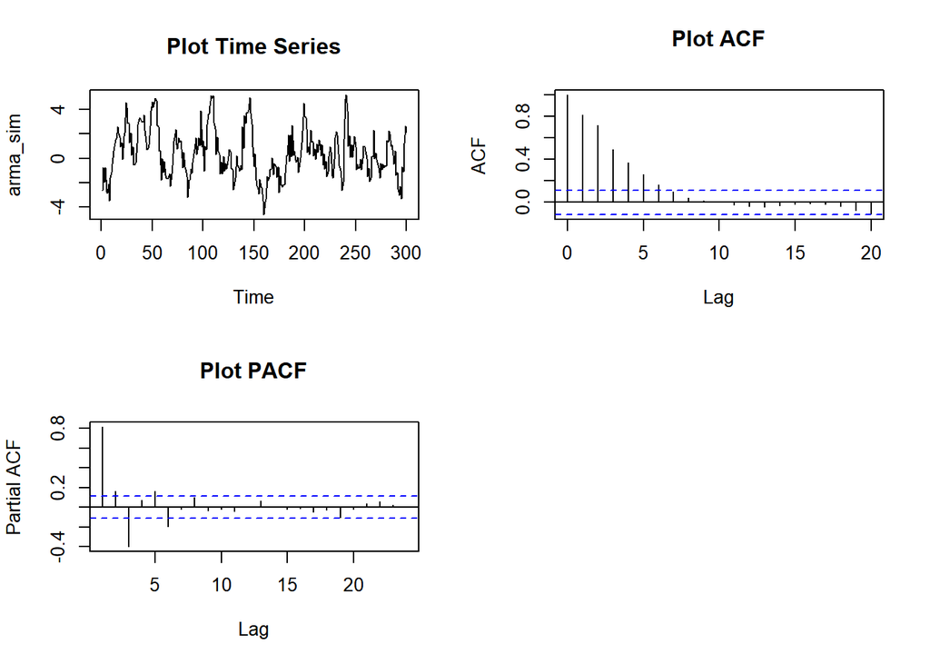

```r
par(mfrow=c(2,2))

# Plot Time Series
ts.plot(arma_sim, main="Plot Time Series")

# Plot ACF
acf(arma_sim, lag.max = 20, main="Plot ACF")

# Plot PACF
pacf(arma_sim, main="Plot PACF")

# Reset the plot layout
par(mfrow=c(1,1))
```

Dari Ketiga poin tersebut, data tergolong stasioner.

### Plot EACF

```r
TSA::eacf(arma_sim)
```

```
## AR/MA
##   0 1 2 3 4 5 6 7 8 9 10 11 12 13
## 0 x x x x x x o o o o o  o  o  o
## 1 x x x o o o o o o o o  o  o  o
## 2 x x o o o o o o o o o  o  o  o
## 3 x x o x x o o o o x o  o  o  o
## 4 x x x o x o o o o x o  o  o  o
## 5 x x x x x o o o o x o  o  o  o
## 6 x x o x x o o o o o o  o  o  o
## 7 x x x o x o o o o o o  o  o  o
```

Membentuk segitiga nol pada p=1, q=3 (AR(1) dan MA(3)). Oleh karena itu, kandidat model dari EACF adalah ARIMA(1,0,3)

### Scatterplot dan Korelasi

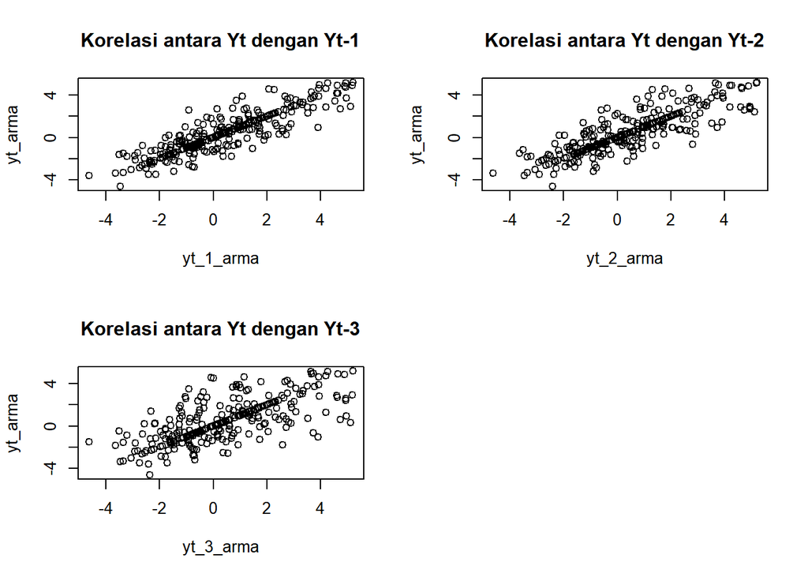

```r
par(mfrow=c(2,2))

# Korelasi antara Yt dengan Yt-1
# Yt
yt_arma <- arma_sim[-1]
# Yt-1
yt_1_arma <- arma_sim[-200]
plot(y=yt_arma,x=yt_1_arma, main="Korelasi antara Yt dengan Yt-1")
cor_1 <- cor(yt_arma,yt_1_arma)

# Korelasi antara Yt dengan Yt-2
# Yt
yt_arma <- arma_sim[-c(1,2)]
# Yt-2
yt_2_arma <- arma_sim[-c(199,200)]
plot(y=yt_arma,x=yt_2_arma, main="Korelasi antara Yt dengan Yt-2")
cor_2 <- cor(yt_arma,yt_2_arma)

# Korelasi antara Yt dengan Yt-3
# Yt
yt_arma <- arma_sim[-c(1,2,3)]
# Yt-3
yt_3_arma <- arma_sim[-c(198,199,200)]
plot(y=yt_arma,x=yt_3_arma, main="Korelasi antara Yt dengan Yt-3")
cor_3 <- cor(yt_arma,yt_3_arma)
```

```r
# Tabel Korelasi
cor_table <- data.frame(Yt_1 = cor_1, Yt_2 = cor_2, Yt_3 = cor_3)
print(cor_table)
```

```
##        Yt_1     Yt_2      Yt_3
## 1 0.8804934 0.839583 0.6884878
```

Berdasarkan scatterplot tersebut, terdapat hubungan linear positif antara $Y_t$ dengan $Y_{t-1}$, $Y_{t-2}$, $Y_{t-3}$. Penurunan tingkat korelasi antara $Y_t$,$Y_{t-2}$ ke $Y_t$,$Y_{t-3}$ cukup jauh menurun sebesar sekitar 0,15.